# Maintaining beach access — PROFEPA capacity & municipal ZOFEMAT coverage

OHI Gulf of California / beach access pressure

2026-07-30

# 1 Why this indicator

Equitable beach access in Mexico rests on federal law: public transit on beaches and the Zona Federal Marítimo Terrestre (ZOFEMAT) must not be impeded. When hotels, condos, or gates block that access, **opening it again depends on enforcement capacity**, not only on municipal fee collection.

This report tracks three capacity signals that can be built from public data:

1. **PROFEPA authorized plazas** (whole agency) — raw and per capita
2. **PROFEPA inspection-program PEF** — raw, inflation-adjusted, and inflation-adjusted per capita
3. **Share of study municipalities with an active municipal ZOFEMAT office**, by **OHI marine region**

> **Core caveat:** PROFEPA covers *all* federal environmental inspection (industry, wildlife, ANPs, forests, ports, ZOFEMAT…). PEF plazas cannot be split into an “inspection program” series; inspection **budget** can (PP 005→014). Neither series is ZOFEMAT-only. Treat both as **upper-bound envelopes of capacity that could be applied to blocked beaches**.

# 2 Agencies and how blocked access is handled

ZOFEMAT is **federal national property**. Public use of the beach and transit to the sea must not be impeded. Occupation of the federal strip normally needs a SEMARNAT concession. Walls, gates, private guards, or “guests only” barriers on or to the beach are classic enforcement cases.

## 2.1 Who does what

| Actor | Role |
| --- | --- |
| **Public / NGOs / visitors** | Notice blockage; file complaints |
| **Municipal ZOFEMAT** (where it exists) | Local front desk — derechos, cleaning, anuencias, documentation, soft pressure. **Cannot** grant federal concessions or usually issue federal clausuras |
| **SEMARNAT / DGZFMTAC** | Concession authority (who may occupy; delimitation). National unit; **not** the main beach-access policeman |
| **PROFEPA** (state Oficina de Representación + national capacity) | **Main enforcement engine** — inspects; can order temporary closure, fines, removal |

## 2.2 How a complaint typically moves (example: La Paz)

1. Someone finds a gated path or wall blocking beach access.
2. They may contact **municipal ZOFEMAT** (in La Paz: Tesorería ZOFEMAT) *or* go straight to **PROFEPA BCS**.
3. The municipality can check occupancy/derechos and urge reopening; if the actor refuses, the case needs **PROFEPA**.
4. PROFEPA receives a **denuncia** (state office or hotline **01 800 776 3372**), inspects, and may impose measures.
5. SEMARNAT enters if the core problem is a missing or illegal concession.

**Implication:** municipal offices help routing and soft management; **sustained libre acceso under development pressure depends on PROFEPA capacity** — measured here with plazas + inspection funding — plus whether a local ZOFEMAT desk even exists to receive complaints.

## 2.3 Why both plazas and inspection budget

| Series | Isolatable as “inspection”? | Interpretation |
| --- | --- | --- |
| **PROFEPA plazas** | **No** (agency-wide; PEF plazas lack a programa presupuestario split) | Best available **people** envelope |
| **PROFEPA inspection PEF** | **Yes** (PP 005 through 2025 / PP 014 in 2026) | Money tagged to the inspection program — closer to enforcement operations than total PROFEPA $ |

People are usually the better capacity signal, but only the budget side cleanly isolates the inspection component. Using **both** is intentional.

# 3 Indicator 1 — PROFEPA plazas (raw and per capita)

**Source:** PEF *Analítico de Plazas* for UR E00 (PROFEPA). Counts are **authorized posts**, not necessarily filled headcount. Job titles include only a small number of explicit “Inspector Especializado…” posts; most plazas are other roles that may still support inspection.

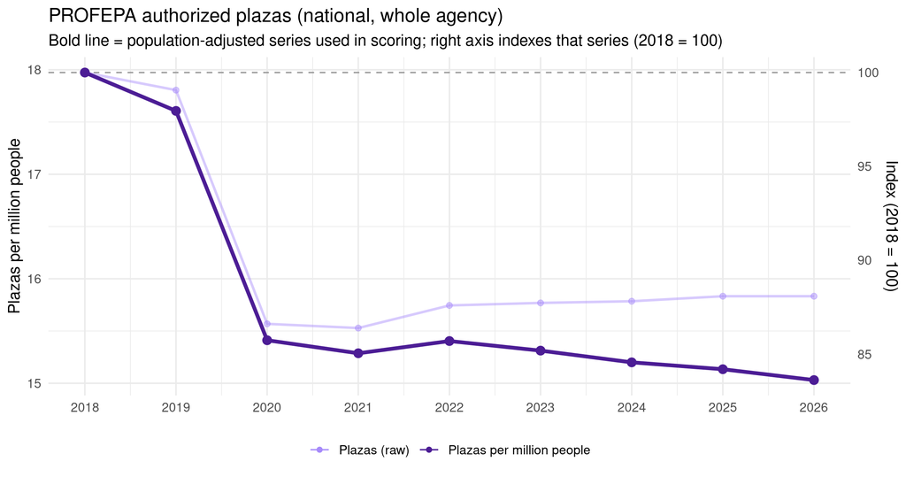

National PROFEPA plazas

| Year | Plazas | Per million people | Index raw | Index per capita |
| --- | --- | --- | --- | --- |
| 2018 | 2242 | 17.97 | 100.0 | 100.0 |
| 2019 | 2221 | 17.61 | 99.1 | 98.0 |
| 2020 | 1942 | 15.41 | 86.6 | 85.7 |
| 2021 | 1937 | 15.29 | 86.4 | 85.1 |
| 2022 | 1964 | 15.40 | 87.6 | 85.7 |
| 2023 | 1967 | 15.31 | 87.7 | 85.2 |
| 2024 | 1969 | 15.20 | 87.8 | 84.6 |
| 2025 | 1975 | 15.13 | 88.1 | 84.2 |
| 2026 | 1975 | 15.03 | 88.1 | 83.6 |

Plazas fell around 2020 (≈2242 → ≈1942) and remained near ≈1975 through 2026 — **below 2018**, especially per capita.

# 4 Indicator 2 — PROFEPA inspection PEF (raw, real, real per capita)

**Series:** authorized PEF for PROFEPA’s inspection program — **PP 005** (2018–2025) / **PP 014** (2026).  
**Inflation:** annual-average **INPC** (base 2Q Jul 2018 = 100); amounts expressed in **constant 2018 MDP**.  
**Per capita:** real MDP ÷ Mexico population (millions).

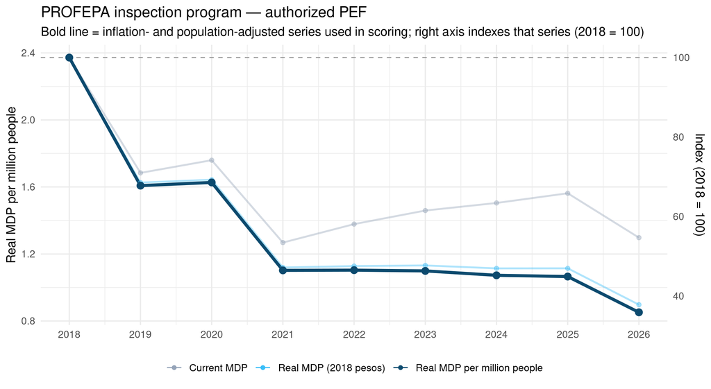

Inspection PEF — current, real, and real per capita

| Year | Current MDP | Real MDP (2018) | Real MDP / M people | INPC |
| --- | --- | --- | --- | --- |
| 2018 | 295.9 | 295.9 | 2.37 | 100.3 |
| 2019 | 210.1 | 202.9 | 1.61 | 103.8 |
| 2020 | 219.5 | 205.0 | 1.63 | 107.3 |
| 2021 | 158.2 | 139.7 | 1.10 | 113.5 |
| 2022 | 171.9 | 140.7 | 1.10 | 122.5 |
| 2023 | 182.0 | 141.2 | 1.10 | 129.3 |
| 2024 | 187.7 | 139.0 | 1.07 | 135.4 |
| 2025 | 194.9 | 139.0 | 1.07 | 140.5 |
| 2026 | 161.9 | 111.9 | 0.85 | 145.0 |

In current pesos, inspection PEF fell from ~296 MDP (2018) to ~162 MDP (2026). In **real** terms the decline is steeper; real **per capita** capacity is weaker still. For access maintenance, the relevant story is whether this envelope keeps up with coastal pressure — here it has declined.

# 5 Indicator 3 — Municipal ZOFEMAT coverage by OHI region

**Universe:** the 25 municipios that contain the 41 beach-access study localities.  
**Active office:** `has_local_zofemat_office = yes` from open-web inventory (15 Jul 2026) — La Paz, Los Cabos, Puerto Peñasco, Bahía de Banderas.  
**Region assignment:** INEGI locality polygons for study localities → centroid → intersect/nearest **marine** OHI region (`spatial/ohi_regions/goc_ohi_rgns.shp`). Each study municipio maps to one region in this set.

**Metric:** for each OHI region with ≥1 study municipio,  
$\text{proportion} = n_{\text{municipios with active ZOFEMAT}} / n_{\text{study municipios in region}}$.

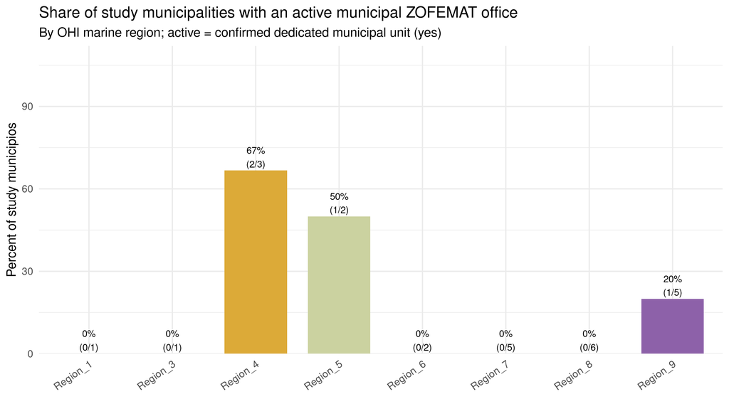

Municipal ZOFEMAT coverage by OHI region (study municipios only)

| Region | Name | Study municipios | With active ZOFEMAT | Percent | Active municipios | All study municipios |
| --- | --- | --- | --- | --- | --- | --- |
| Region_1 | Western Upper Gulf | 1 | 0 | 0.0 | NA | Mexicali |
| Region_3 | Western Central Gulf | 1 | 0 | 0.0 | NA | Mulegé |
| Region_4 | Western Southern Gulf | 3 | 2 | 66.7 | La Paz; Los Cabos | La Paz; Loreto; Los Cabos |
| Region_5 | Eastern Upper Gulf | 2 | 1 | 50.0 | Puerto Peñasco | Puerto Peñasco; San Luis Río Colorado |
| Region_6 | Eastern Midriff Islands | 2 | 0 | 0.0 | NA | Hermosillo; Pitiquito |
| Region_7 | Southern Sonora Coast | 5 | 0 | 0.0 | NA | Benito Juárez; Empalme; Guaymas; Huatabampo; San Ignacio Río Muerto |
| Region_8 | Sinaloa Coast | 6 | 0 | 0.0 | NA | Ahome; Angostura; Escuinapa; Guasave; Mazatlán; Navolato |
| Region_9 | Southeastern Gulf | 5 | 1 | 20.0 | Bahía de Banderas | Bahía de Banderas; Cabo Corrientes; Compostela; Puerto Vallarta; San Blas |

Overall, **4 of 25** study municipios (16%) have a confirmed active municipal ZOFEMAT office. Most OHI regions with study sites show **0%** coverage; the higher shares are Western Southern Gulf (La Paz / Los Cabos), Eastern Upper Gulf (Puerto Peñasco), and Southeastern Gulf (Bahía de Banderas).

Municipal units facilitate complaints and beach admin; **they do not replace PROFEPA** for forcing open a blocked access.

Detail and contacts: `../local_zofemat/local_zofemat_offices.html`.

# 6 Data weaknesses

1. **Not ZOFEMAT-only.** Inspection PEF and plazas cover all PROFEPA monitoring; beaches are an unknown slice.
2. **Plazas ≠ inspection staff.** PEF plazas have no programa presupuestario field; agency-wide counts only.
3. **Authorized ≠ executed; plazas ≠ filled posts.**
4. **INPC 2026 is provisional** (Jan–May mean) for comparing to PEF 2026.
5. **Population denominators** are national approximations (CONAPO/INEGI).
6. **Municipal “active office”** from Jul 2026 open-web research — offices may exist without public branding; coding is `yes` only when a dedicated unit was found.
7. **OHI assignment** uses locality centroids vs marine regions; municipalities without study localities are out of scope. Region_2 has no study municipios in this set.
8. **State PROFEPA PEF EF tags** are omitted here — they are small CDMX-dominated accounting tags and are not a good proxy for state plazas or office budgets.
9. **DGZFMTAC** is concession admin (national), not used as an enforcement indicator.

# 7 Putting the pieces together

| Component | Desired direction for access maintenance |
| --- | --- |
| PROFEPA plazas (raw + per capita) | Stable or ↑ |
| Inspection PEF (real + real per capita) | Stable or ↑ |
| % municipalities with active ZOFEMAT (by OHI region) | ↑ / gap rates ↓ |

**2018–2026 reading:** national plazas and real inspection funding are **weaker than in 2018**, while many OHI regions have **no** confirmed municipal ZOFEMAT desk among study municipios. That combination does not favor maintaining libre acceso under coastal development pressure. These remain **governance/capacity proxies**, not substitutes for field equitable-access beach scores.

# 8 Sources & outputs

- PEF Programa Presupuestario analiticos 2018–2026 (`sources/pef_analiticos/pp/`)
- PEF Plazas analiticos (`sources/pef_analiticos/plazas/`)
- INPC annual means: `output/indicator_inpc_annual.csv`
- Population: `output/indicator_denominators.csv`
- ZOFEMAT × OHI: `output/indicator_zofemat_by_ohi_region.csv`, `output/study_municipios_ohi_region_zofemat.csv`
- Municipal inventory: `../local_zofemat/`
- Prior narrative summary: `zofemat_budget_enforcement_summary.html`